# (Ford GoBike System Data)

## Preliminary Wrangling

> This data contain the rides of bike in a bike-sharing system in an Francisco Bay area.

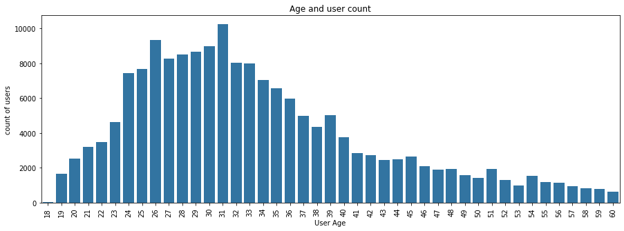

```python
#set the figure size
plt.figure(figsize=[15,5])

#visual the count plot the Age after drpo the outliers
ax=sb.countplot(data=df , x='Age', color=color)
plt.title('Age and user count')
ax.set(xlabel='User Age', ylabel='count of users')
plt.xticks(rotation=90);
```

### Age distribution:

I think thers is outliers in the age so boxplot made it easier to me to get it an delete these outliers (more than 60 years) then i get the count plot it and the most of users between 20 , 40 years.

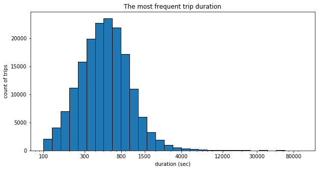

```python
#set figure size
plt.figure(figsize=[10, 5])

#set hist bins
bins = 10 ** np.arange(2, 5.0 + 0.1, 0.1)

#visuale the histgrame of the duration_sec
plt.hist(data=df, x='duration_sec', bins=bins , edgecolor='black')
x_ticks = [100,300,800, 1500, 4000, 12000, 30000, 80000]
labels = ['{}'.format(val) for val in x_ticks]
#scale x axis
plt.xscale('log')
plt.xticks(x_ticks, labels)
plt.xlabel('duration (sec)')
plt.ylabel('count of trips')
plt.title('The most frequent trip duration');
```

### Duration distribution in sec

Most of the points are less than 2000 seconds with about 500 seconds peak.

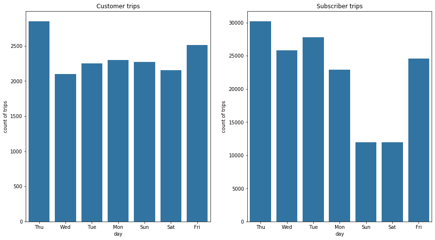

```python
#set the figure size
plt.figure(figsize=[15,8])

#get color fron seaborn palette
color=sb.color_palette()[0]

plt.subplot(1,2,1)

#visual the countplot of customer on week days
ax=sb.countplot(data=df[df['user_type']=='Customer'] , x='trip_day' , color=color)
plt.title('Customer trips')
ax.set(xlabel='day', ylabel='count of trips');

plt.subplot(1,2,2)

#visual the countplot of customer on week days
ax=sb.countplot(data=df[df['user_type']=='Subscriber'] , x='trip_day' , color=color)
plt.title('Subscriber trips')
ax.set(xlabel='day', ylabel='count of trips');
```

### User Types Vs week days

> - According to this visuale, i noticed that in the subscriber type in the weekends (sun , sat) is the least count of trips. so that i think they use their bikes to go work.
> - According to this visuale, i noticed that in the customer trips are over the week but thursday is the the most trips.

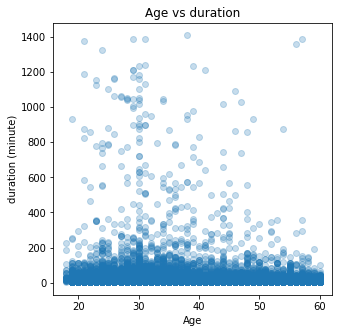

```python
#set the figure size
plt.figure(figsize=[5,5])

#the scatter plot define the relation between the Age an duration in minutes
ax=sb.regplot(data=df , x='Age',y='duration' ,fit_reg=False ,scatter_kws ={'alpha':1/4})

#set the visual title
plt.title('Age vs duration')
ax.set(xlabel='Age', ylabel='duration (minute)');
```

### Duration Vs Age

> - As most of the durations are below 200 minutes and age is below 60.
> - the more Age increase the duration less slightly not as i expected.

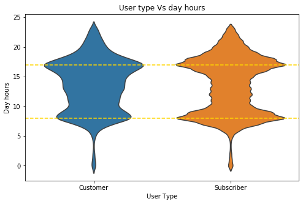

```python
#set the figure size
plt.figure(figsize=[8,5])

#set the violin plot between the user type and the day hours of the trip
sb.violinplot(data=df , x='user_type' , y='trip_hour' , inner=None);
plt.xlabel('User Type')
plt.ylabel('Day hours')
plt.title('User type Vs day hours')

#set gold lines in the most wide edges
plt.axhline(y=8 , color='gold' , linestyle='--')
plt.axhline(y=17 , color='gold' , linestyle='--');
```

### user type VS day hours

> - The most rides are in 8 am and 17 pm.

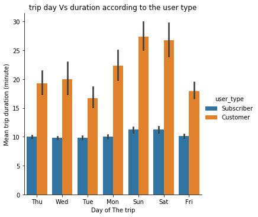

```python
#set the user type order by i's count
type_order=df['user_type'].value_counts().index

#set bar plot between the day of trip and the mean of trip dration in minutes
sb.catplot(data=df, kind='bar', x='trip_day', y='duration', hue='user_type' , hue_order=type_order )

plt.xlabel('Day of The trip')
plt.ylabel('Mean trip duration (minute)')
plt.title('trip day Vs duration according to the user type');
```

### Mean trip duration for both user types across week days

> The mean of trip duration fo customers are more than subscribers specially in Weekends

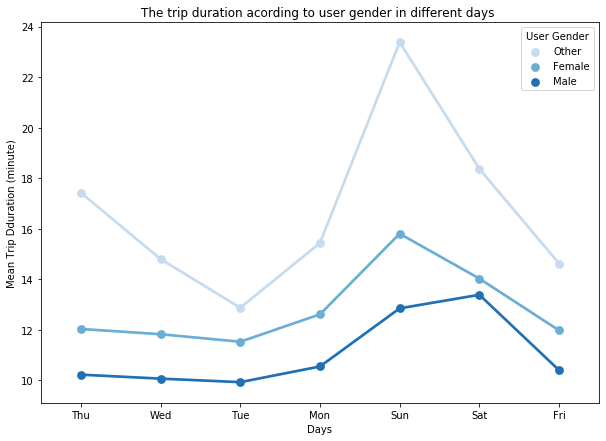

```python
#set the figure size
fig = plt.figure(figsize = [10,7])

#set the point plot between day of the trip and duration of each member gender
sb.pointplot(data = df, x = 'trip_day', y = 'duration', hue = 'member_gender',hue_order=gender_order[::-1] ,palette = 'Blues', ci=None)

#set the title of the hue
plt.legend(title='User Gender')
plt.title('The trip duration acording to user gender in different days ')
plt.ylabel('Mean Trip Dduration (minute)')
plt.xlabel('Days');
```

### The trip duration acording to user gender in different days

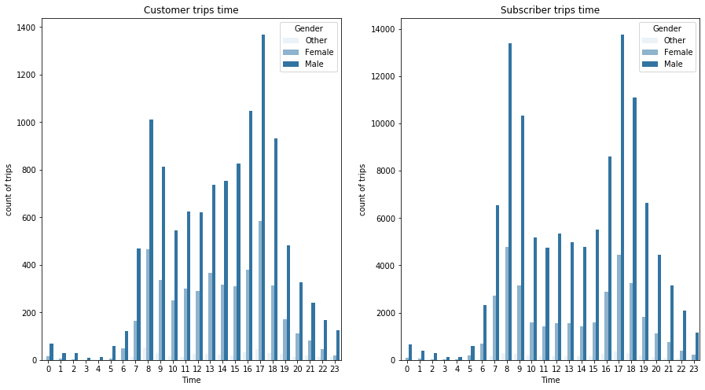

```python
#set the figure size
plt.figure(figsize=[15,8])

plt.subplot(1,2,1)

#count plot the day hours of trip for the customer user and gender
ax=sb.countplot(data=df[df['user_type']=='Customer'] , x='trip_hour', hue='member_gender' ,hue_order=gender_order[::-1] , color=color)
plt.title('Customer trips time')
ax.set(xlabel='Time', ylabel='count of trips')
plt.legend(title='Gender');

plt.subplot(1,2,2)

#count plot the day hours of trip for the subscriber user and gender
ax=sb.countplot(data=df[df['user_type']=='Subscriber'] , x='trip_hour', hue='member_gender' ,hue_order=gender_order[::-1], color=color)
plt.title('Subscriber trips time')
ax.set(xlabel='Time', ylabel='count of trips')
plt.legend(title='Gender');
```

### Customer and subscriber trip times and gender

i want to explore that if there is relation between the user type and Time and put gender in my exploration.